# Initial writeup_LSTM

Pei-Yin Yang

7/4/2022

### Intro to Long Short-Term Memory (LSTM) Recurrent Neural Network

LSTM is a variety of RNN. The benefit of the Long Short-Term Memory (LSTM) network over other recurrent networks comes from an improved method of back-propagating the error. Hochreiter and Schmidhuber called it “constant error back propagation” (Hochreiter and Schmidhuber 1997).

The Constant Error Carousel (CEC) is the magic of the LSTM in that it prevents vanishing gradients. It’s denoted as follows:

$c_{t+1}=c_{t}$ ∗ forget gate + new input ∗ input gate

In the case of regular RNNs during backpropagation, the derivative of an activation function, such as a logistic, will be less than one. Therefore over time, the repeated multiplication of that value against the weights will lead to a vanishing gradient.

In the case of an LSTM, we only multiply the cell state by a forget gate, which acts as both the weights and the activation function for the cell state. As long as that forget gate equals one, the information from the previous cell state passes through unchanged. This is why LSTM can deal with more intricate problems than the RNN by keeping a constant flow of error throughout the backpropagation from cell to cell.

### LSTM forecasting Bike Rental demand

### Methods

#### Data processing

**Normalization**

It is a good idea for machine learning algorithms that fit a model that uses a weighted sum of input variables, such as linear regression, logistic regression, and artificial neural networks (deep learning) to normalize the data(Brownlee 2020). Here, by using the scikit-learn object *MinMaxScaler*, the normalization scales each input variable separately to the range [0,1], which is the range for floating-point values where we have the most precision. A value is normalized as follows:

- y = (x-min) / (max-min)

**Use the following *series_to_supervised()* function to transform the dataset**

```python
# convert series to supervised learning
def series_to_supervised(data, n_in=1, n_out=1, dropnan=True):
    n_vars = 1 if type(data) is list else data.shape[1]
    df = DataFrame(data)
    cols, names = list(), list()
    # input sequence (t-n, ... t-1)
    for i in range(n_in, 0, -1):
        cols.append(df.shift(i))
        names += [('var%d(t-%d)' % (j+1, i)) for j in range(n_vars)]
    # forecast sequence (t, t+1, ... t+n)
    for i in range(0, n_out):
        cols.append(df.shift(-i))
        if i == 0:
            names += [('var%d(t)' % (j+1)) for j in range(n_vars)]
        else:
            names += [('var%d(t+%d)' % (j+1, i)) for j in range(n_vars)]
    # put it all together
    agg = concat(cols, axis=1)
    agg.columns = names
    # drop rows with NaN values
    if dropnan:
        agg.dropna(inplace=True)
    return agg
```

#### Network Training and Forecasting

A built-in library - Keras in Python, developed by Google, is used for model building. Each input data was a list of lagged hours of bike rental count and the output data for that particular input was the bike demand for the next hour. One-hour, 12-hour, and 24-hour lagged timestep are used for the input data. The processed dataset was partitioned into train and test set where about 86% of the total data was used for model training and the remaining 14% was used for testing. Table 1. shows the implementation details.

Table 1. Details of the LSTM model setup.

[output not shown]

**Definition of Hyper-parameters**

- nodes(neurons): units accepting a vector of real-valued inputs and producing a single real-valued output.
- batch size: how many obs. are used at each step, converge faster with a larger value.
- epoch: an iteration over all training obs.
- dropout: regularization method to prevent over-fitting
- learning rate: define how quickly the network updates its parameters

**Hyper-parameter tuning is on the to-do list**

#### Model Evaluation

Forecast performance was assessed using Mean Absolute Error (MAE), Root Mean Square Error (RMSE), and the learning curve. A good fit is identified by a training and validation loss that decreases to a point of stability with a minimal gap between the two final loss values.

#### **1 hour lagged time steps as input**

#### **1 hour lagged time steps as input - Model Architecture**

1. LSTM with 50 neurons in the first visible layer
2. Dropout 50%
3. 1 neuron in the output layer for predicting Bike Demand.
4. The input shape will be 1 time step with 12 features.
5. I use the Mean Absolute Error (MAE) loss function and the efficient Adam version of stochastic gradient descent.
6. The model will be fit for 80 training epochs with a batch size of 12.

There more extensions can be tried out.

Layers, regularization, optimization algorithm, etc.

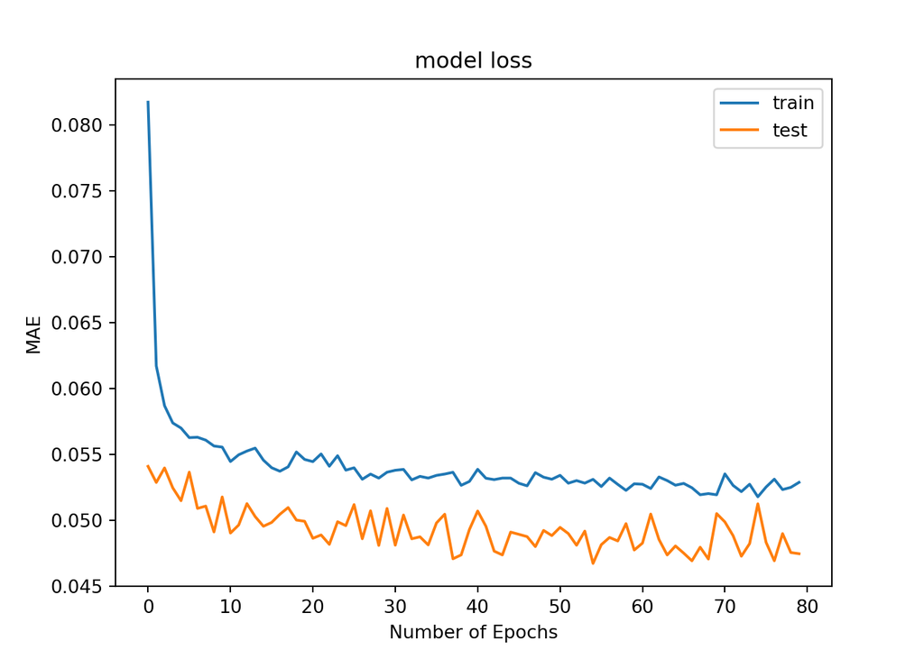

Figure 1. Model loss - 1 hour lagged time steps as input

Although from figure 1. we can see both errors converge fairly fast, the proposed network is not a good fit since there is a gap between the training error and test error.

```
## Test RMSE: 275.821
```

```
## Test mean absolute error : 168.806
```

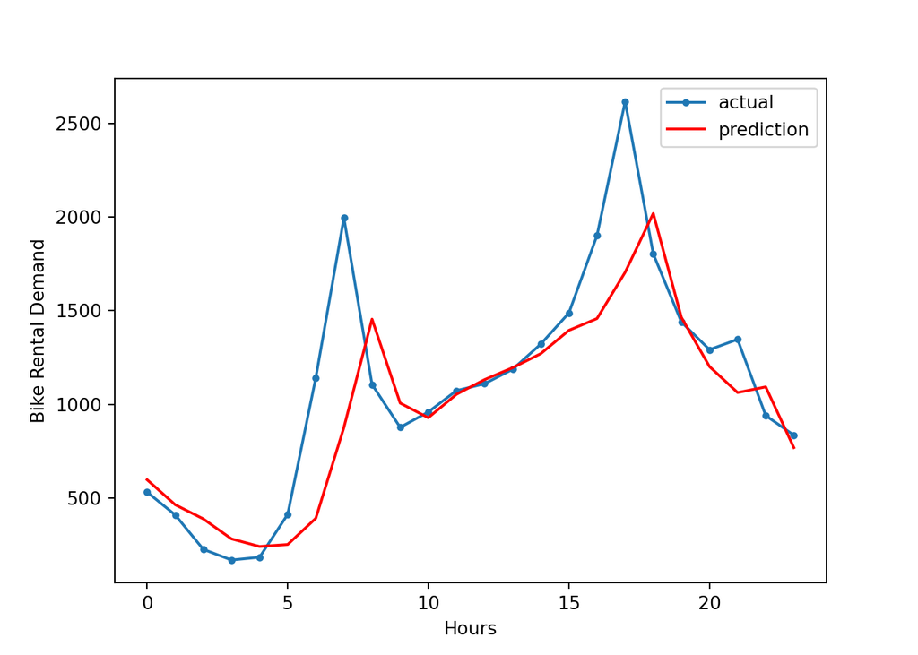

Figure 2. Forcasted Bike Rental Demand of one day - 1 hour lagged time steps as input

#### **12 hour lagged time steps as input**

#### **12 hour lagged time steps as input - Model Architecture**

1. LSTM with 50 neurons in the first visible layer
2. Dropout 50%
3. 1 neuron in the output layer for predicting Bike Demand.
4. The input shape will be 12 time step with 12 features.
5. I use the Mean Absolute Error (MAE) loss function and the efficient Adam version of stochastic gradient descent.
6. The model will be fit for 60 training epochs with a batch size of 12.

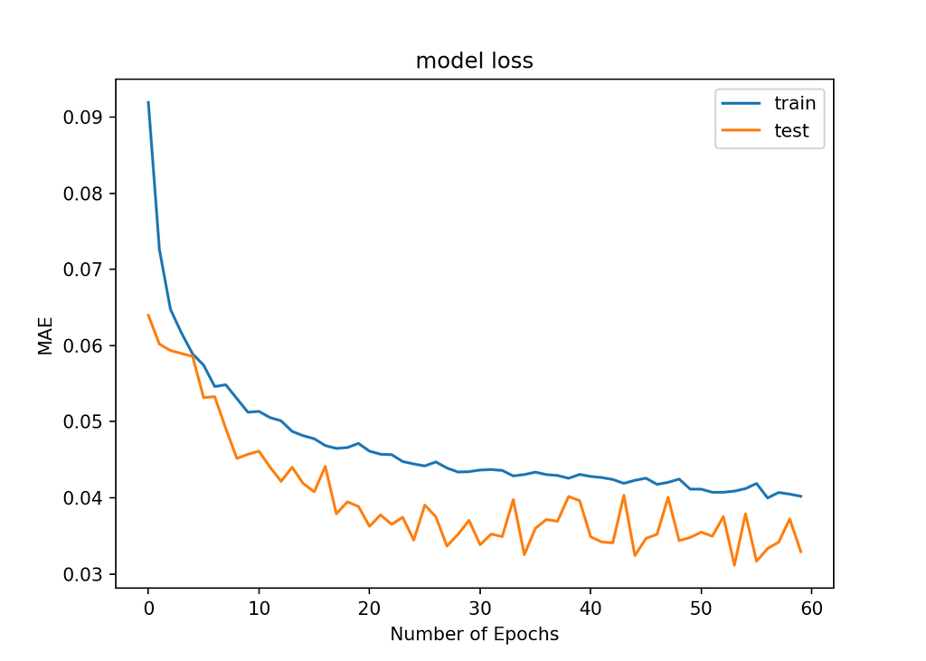

Figure 3. Model loss - 12 hour lagged time steps as input

```
## Test RMSE: 158.083
```

```
## Test mean absolute error : 117.152
```

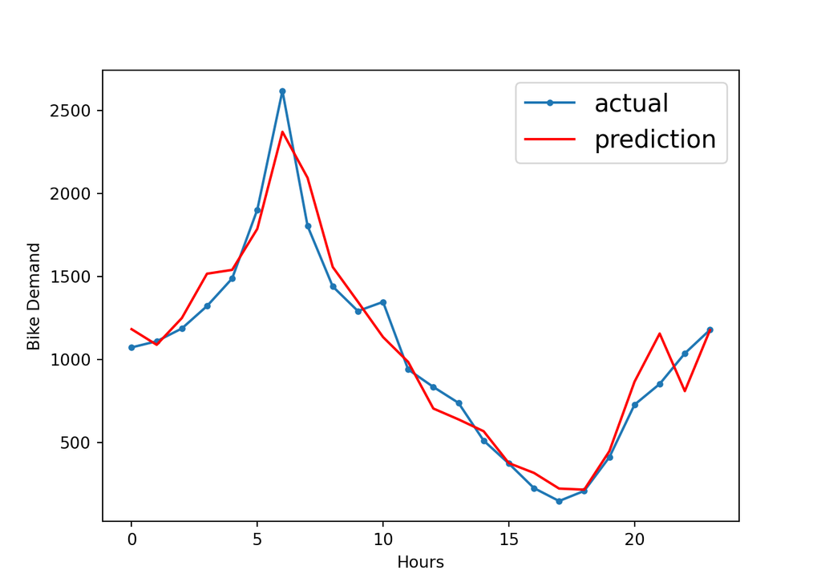

Figure 4. Forcasted Bike Rental Demand of one day - 12 hour lagged time steps as input

#### **24 hour lagged time steps as input**

```
## (8760, 12)
```

```
##     var1(t-24)  var2(t-24)  var3(t-24)  ...  var10(t)  var11(t)  var12(t)
## 24    0.071429    0.220280    0.377551  ...       1.0       1.0       1.0
## 25    0.057368    0.215035    0.387755  ...       1.0       1.0       1.0
## 26    0.048650    0.206294    0.397959  ...       1.0       1.0       1.0
## 27    0.030090    0.202797    0.408163  ...       1.0       1.0       1.0
## 28    0.021935    0.206294    0.367347  ...       1.0       1.0       1.0
##
## [5 rows x 300 columns]
```

```
## (8736, 300)
```

```python
# split into train and test sets
values = reframed.values
N = len(dataset.index)
days_for_cv = 50
n_train_hours = (N - days_for_cv* 24 )
#n_train_hours = int(N * 0.7)
train = values[:n_train_hours, :]
test = values[n_train_hours:, :]
# split into input and outputs
n_obs = n_hours * n_features
train_X, train_y = train[:, :n_obs], train[:, -n_features]
test_X, test_y = test[:, :n_obs], test[:, -n_features]
print(train_X.shape, len(train_X), train_y.shape)
```

```
## (7560, 288) 7560 (7560,)
```

```python
# reshape input to be 3D [samples, timesteps, features]
train_X = train_X.reshape((train_X.shape[0], n_hours, n_features))
test_X = test_X.reshape((test_X.shape[0], n_hours, n_features))
print(train_X.shape, train_y.shape, test_X.shape, test_y.shape)
```

```
## (7560, 24, 12) (7560,) (1176, 24, 12) (1176,)
```

#### **24 hour lagged time steps as input - Model Architecture**

1. LSTM with 50 neurons in the first visible layer
2. Dropout 50%
3. 1 neuron in the output layer for predicting Bike Demand.
4. The input shape will be 24 time step with 12 features.
5. I use the Mean Absolute Error (MAE) loss function and the efficient Adam version of stochastic gradient descent.
6. The model will be fit for 60 training epochs with a batch size of 12.

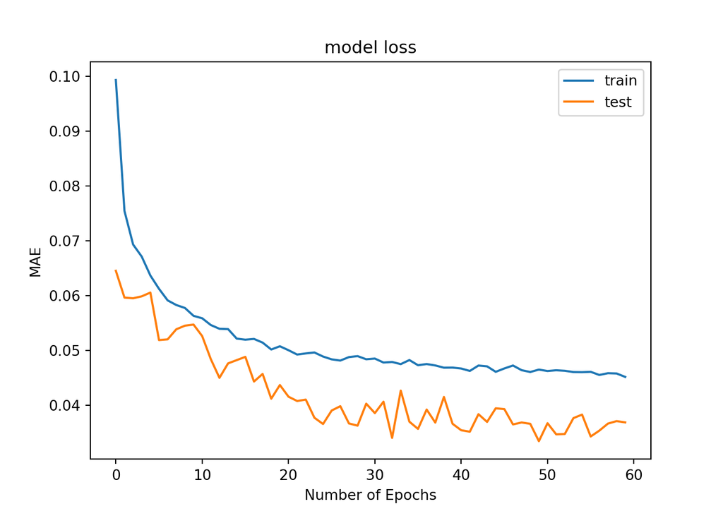

Figure 5. Model loss - 24 hour lagged time steps as input

```
## Test RMSE: 178.123
```

```
## Test mean absolute error : 130.965
```

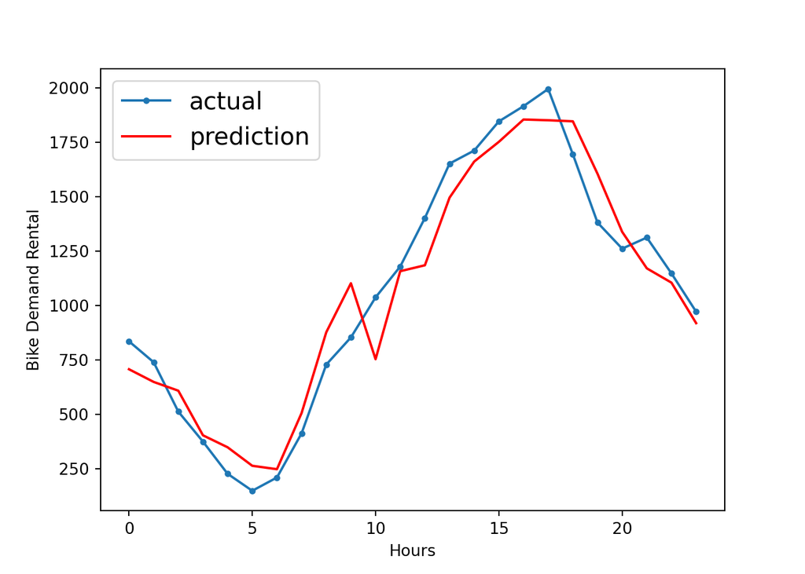

Figure 6. Forcasted Bike Rental Demand of one day - 24 hour lagged time steps as input

Brownlee, Jason. 2020. “How to Use StandardScaler and MinMaxScaler Transforms in Python.” Machine Learning Mastery. https://machinelearningmastery.com/standardscaler-and-minmaxscaler-transforms-in-python/.

Hochreiter, Sepp, and Jürgen Schmidhuber. 1997. “Long Short-Term Memory.” *Neural Computation* 9 (November): 1735–80. https://doi.org/10.1162/neco.1997.9.8.1735.